Correction rédigée par Téofil Adamski.

# Exercice 1

## Question 1

```python
V(x, y) = (-y, x)
V.div()
```

```
(x, y) |--> 0
```

## Question 2

```python
def euler(V, T, h, x0, y0):
    for _ in range(0, int(T/h)):
        (x0, y0) = (x0 + h * V(x=x0, y=y0)[0],
                    y0 + h * V(x=x0, y=y0)[1])
    return (x0, y0)

h = 0.01
(x0, y0) = (2, 0)
euler(V, 1, h, x0, y0), euler(V, 2, h, x0, y0), euler(V, 10, h, x0, y0)
```

```
((1.08607726866470, 1.69134112906336),
 (-0.840535490675573, 1.83692715383341),
 (-1.76456003640809, -1.14323639214487))
```

# Questions 3 & 4

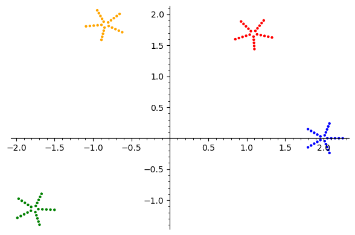

```python
def etoile_transportee(V):
    m = 5
    pi = 3.14159
    P = [(2 + i / (4 * m) * cos(2 * pi * j / m),
          i / (4 * m) * sin(2 * pi * j / m))
         for i in range(1, m + 1) for j in range(1, m + 1)]
    fig = point(P)

    for (T, c) in [(1, 'red'), (2, 'orange'), (10, 'green')]:
        P1 = []
        for (x0, y0) in P:
            P1.append(euler(V, T, h, x0, y0))
        fig += point(P1, color=c)

    return fig

etoile_transportee(V).show()
```

L'étoile tourne autour de l'origine. Elle ne change pas de taille : cela s'explique par le fait que la divergence du champ $V$ est nulle.

## Question 5

### Deuxième champ de vecteurs

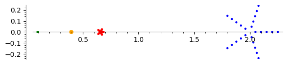

```python
V(x, y) = (-x^2 + y^2,  -2 * x * y)
etoile_transportee(V).show(aspect_ratio=1)
```

Cette fois-ci, l'étoile se rapproche de l'origine et sa taille diminue avec le temps. Ce dernier point s'explique par le fait que la divergence est strictement négative sur le demi-plan $\{x > 0\}$.

```python
V.div()
```

```
(x, y) |--> -4*x
```

### Troisième champ de vecteurs

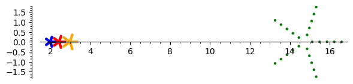

```python
V(x, y) = (x / 5, y / 5)
etoile_transportee(V).show(aspect_ratio=1)
```

L'étoile s'éloigne de l'origine selon le vecteur $(1, 0)$ et sa taille augmente puisque la divergence est positive.

```python
V.div()
```

```
(x, y) |--> 2/5
```

# Exercice 2

## Question 1

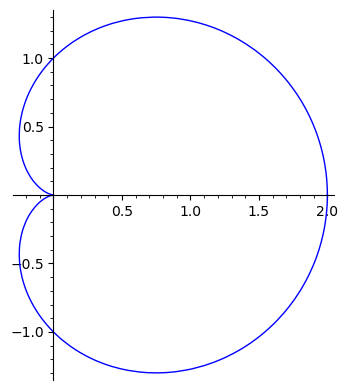

```python
t = var('t')
C = [cos(t) * (1 + cos(t)), sin(t) * (1 + cos(t))]
parametric_plot(C, (t, 0, 2 * pi))
```

## Question 2

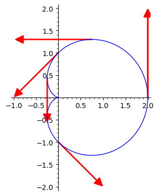

```python
def vecteurs(t0):
    return ((C[0](t=t0), C[1](t=t0)),
            (C[0].diff()(t=t0), C[1].diff()(t=t0)))


fig = parametric_plot(C, (t, 0, 2 * pi))

for t0 in [0, pi / 3, pi / 2, 2 * pi / 3, pi, 3 * pi / 2, 2 * pi]:
    P, v = vecteurs(t0)
    Q = (P[0] + v[0], P[1] + v[1])
    fig += arrow(P, Q, color='red')

fig
```

## Question 3

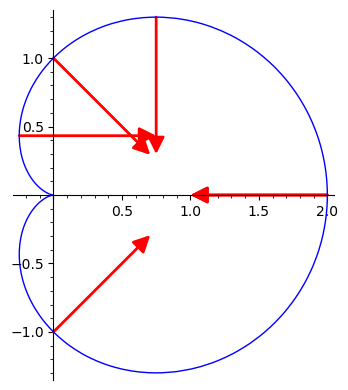

```python
fig = parametric_plot(C, (t, 0, 2 * pi))

for t0 in [0, pi / 3, pi / 2, 2 * pi / 3, 3 * pi / 2, 2 * pi]:
    P, v = vecteurs(t0)
    norme = sqrt(v[0]^2 + v[1]^2)
    Q = (P[0] - v[1] / norme, P[1] + v[0] / norme)
    fig += arrow(P, Q, color='red')

fig
```

Le point d'angle $\theta = \pi$ est un point singulier de la courbe. Cette dernière n'a donc ni vecteur tangent ni vecteur normal en ce point.

## Question 4

La longueur $L$ de la courbe $\gamma \colon t \in [0, 2\pi] \longmapsto (\cos t(1 + \cos t), \sin t(1 + \cos t))$ vaut \begin{align*} L &= \int_0^{2\pi} \lVert\gamma'(t)\rVert \,\mathrm dt \\ &= \int_0^{2\pi} \sqrt{[-\sin t - 2\sin t\cos t]^2 + [\cos t + \cos^2t - \sin^2t]^2} \,\mathrm dt \\ &= \int_0^{2\pi} \sqrt{\sin^2t[1 + 2\cos t]^2 + [\cos t(1 + \cos t) - \sin^2t]^2} \,\mathrm dt \\ &= \int_0^{2\pi} \sqrt{\sin^2t(1 + 4\cos t + 4\cos^2t) + \cos^2t(1 + \cos t)^2 - 2\cos t(1 + \cos t)\sin^2t + \sin^4t} \,\mathrm dt \\ &= \int_0^{2\pi} \sqrt{\sin^2t(1 + 4\cos t + 4\cos^2t) + \cos^2t(1 + 2\cos t + \cos^2t) - 2\cos t(1 + \cos t)\sin^2t + \sin^4t} \,\mathrm dt \\ &= \int_0^{2\pi} \sqrt{\sin^2t(1 + 2\cos t + 2\cos^2t) + \cos^2t(1 + 2\cos t + \cos^2t) + \sin^4t} \,\mathrm dt \\ &= \int_0^{2\pi} \sqrt{\sin^2t(1 + 2\cos t + 2\cos^2t) + \cos^2t(1 + 2\cos t + 2\cos^2t) - \cos^4t + \sin^4t} \,\mathrm dt \\ &= \int_0^{2\pi} \sqrt{(1 + 2\cos t + 2\cos^2t + \sin^4t - \cos^4t} \,\mathrm dt \\ &= \int_0^{2\pi} \sqrt{1 + 2\cos t + 2\cos^2t + (\sin^2t + \cos^2t)(\sin^2t - \cos^2t)} \,\mathrm dt \\ &= \int_0^{2\pi} \sqrt{1 + 2\cos t + 2\cos^2t + \sin^2t - \cos^2t} \,\mathrm dt \\ &= \int_0^{2\pi} \sqrt{2 + 2\cos t} \,\mathrm dt. \end{align*} Or pour tout réel $t \in \mathbf R$, on sait que $2\cos^2t = 1 + \cos(2t)$ ce qui donne $2\cos^2(t/2) = 1 + \cos t$. On en déduit \begin{align*} L &= 2 \int_0^{2\pi} \lvert\cos(t/2)\rvert \,\mathrm dt \\ &= 2 \left(\int_0^\pi \cos(t/2) \,\mathrm dt - \int_\pi^{2\pi} \cos(t/2) \,\mathrm dt\right) \\ &= 2([2\sin(t/2)]_0^{\pi} - [2\sin(t/2)]_\pi^{2\pi}) \\ &= 4(1 - 0 - [0 - 1]) = 8. \end{align*}

```python
norme_diff = sqrt(C[0].diff()^2 + C[1].diff()^2)
L = monte_carlo_integral(norme_diff, [0], [2 * pi], 10^5)
L[0]
```

```
7.983244299003871
```

## Question 5

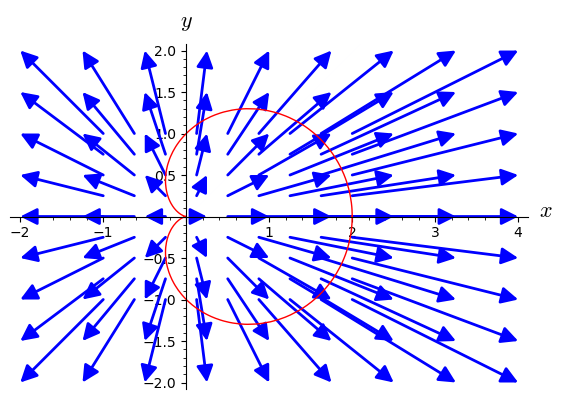

```python
M = Manifold(2, 'M')
X.<x, y> = M.chart()
V = M.vector_field(x, y)

fig = V.plot(ranges={x: (-1, 2), y: (-1, 1)})
fig += parametric_plot(C, (t, 0, 2 * pi), color='red')
fig
```

```python
integrande = C[0] * C[0].diff() + C[1] * C[1].diff()
circulation = monte_carlo_integral(integrande, [0], [2 * pi], 10^6)
circulation[0]
```

```
-0.0013527742081564493
```

On remarque que la circulation est nulle. Cela peut s'expliquer grâce à la symétrie du champ de vecteurs et de la cardoïde par rapport à l'axe des abscisses.

## Question 6

Notons $D \subset \mathbf R^2$ la région délimitée par la courbe $\gamma$. Avec la formule de la divergence, on trouve $$ \iint_D \operatorname{div} V(x, y) \,\mathrm dx \,\mathrm dy = \int_\gamma V \cdot \bar n \,\mathrm d\sigma. $$ Puisque $\operatorname{div} V(x, y) = 2$, l’aire de la région $D$ vaut $$ \iint_D \mathrm dx \,\mathrm dy = \frac12 \int_\gamma V \cdot \bar n \,\mathrm d\sigma. $$

```python
integrande = C[0] * C[1].diff() - C[1] * C[0].diff()
volume = monte_carlo_integral(integrande, [0], [2 * pi], 10^6)
volume[0] / 2
```

```
4.708686428704525
```